# Project 1

# Are there differences in activity patterns between weekdays and weekends?

## For this part the weekdays() function may be of some help here. Use the dataset with the filled-in missing values for this part.

### Create a new factor variable in the dataset with two levels – “weekday” and “weekend” indicating whether a given date is a weekday or weekend day.

### Make a panel plot containing a time series plot (i.e. type = “l”) of the 5-minute interval (x-axis) and the average number of steps taken, averaged across all weekday days or weekend days (y-axis). See the README file in the GitHub repository to see an example of what this plot should look like using simulated data.

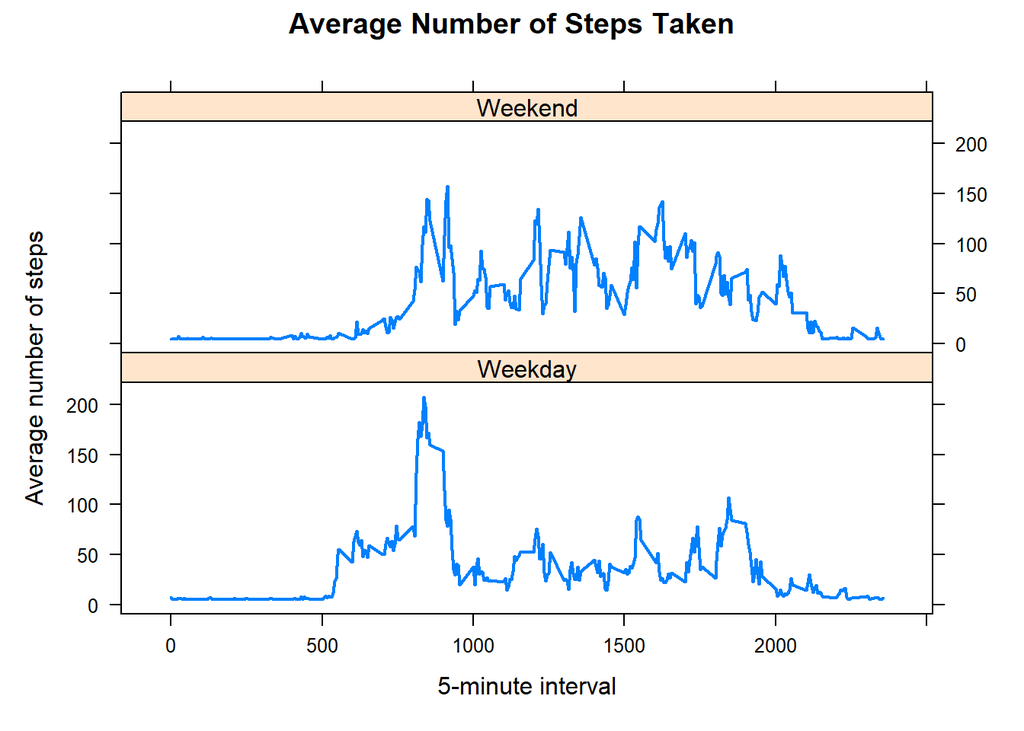

```r
#Create a factor for weekdays
CoolerData$day = weekdays(CoolerData$date)
#Create a new column for weekends/weekdays
CoolerData$week = ""
CoolerData[ CoolerData$day == "Saturday" | CoolerData$day == "Sunday", ]$week = "Weekend"
CoolerData[ !( CoolerData$day == "Saturday" | CoolerData$day == "Sunday" ) , ]$week = "Weekday"
CoolerData$week = factor(CoolerData$week)

#Time Series Plot
ImputedAverageSteps = aggregate(steps ~ interval + week, data = CoolerData, mean)
#install.packages('lattice')
library(lattice)
xyplot(steps ~ interval | week, data = ImputedAverageSteps, type = "l", lwd = 2,
       layout = c(1, 2),
       xlab = "5-minute interval",
       ylab = "Average number of steps",
       main = "Average Number of Steps Taken")
```